# unstruct_pop_models

### 2.3.5 Exponential growth

#### 2.3.5.1 What is exponential growth

For populations which do not reproduce seasonally, an irrestricted growth can be projected using the exponential growth model. Instead of the $\lambda$ rate, the **instantaneous per capita growth rate (r)** is used to represent a constant percentage increase over a continuous time scale. This rate is also useful to compare populations with different intervals of growth.

#### 2.3.5.2 How to calculate the exponential growth rate

Using calculus, very small changes in abundance over time can be obtained by the derivative:

$$dN/dt=rN$$
Where: dN = very small change in abundance dt = very small change in time N = present abundance r = per capita growth rate

#### 2.3.5.3 Abundance over time in a logarithmic scale

If represented in a logarithmic scale, the curve line becomes a straight line, and the slope of the line corresponds to r.

#### 2.3.5.4 Converting between $\lambda$ and r

The natural logarithm of $\lambda$ corresponds to r:

$$r=ln\lambda$$
or

$$\lambda=e^r$$

While $\lambda$ values greater than 1 represent growing populations, r values greater than 0 correspond to population increases in size.

#### 2.3.5.5 Example using duckweeds

In our lab, we work with a group of aquatic plants commonly called duckweeds. Due to their fast and asexual growth, they are good model species for population ecology studies. Duckweed population growth can be calculated in a number of ways, such as counting individual fronds (leaf like shape) or measuring the dry weight of specimens. Try to count how many individuals are found in each date in the picture below. Any round-shaped protuberance can be considered as a separate individual.

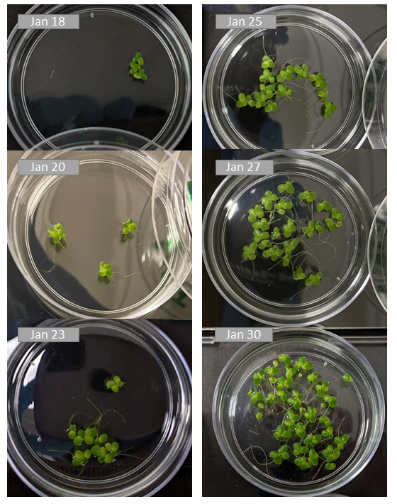

Populations of duckweeds (*Lemna minor*) grown in laboratory conditions and optimal temperature

```r
# Let's create a dataframe using the duckweed population counts we have just obtained from the picture above:
duckweed <- data.frame(day=(c(18,20,23,25,27,30)),pop_size=(c(9,12,23,45,68,103)))

# Now, let's calculate the average daily $\lambda$:
lambda <- (duckweed[6, "pop_size"]/duckweed[1, "pop_size"])^(1/(duckweed[6, "day"]-duckweed[1, "day"]))
```

The average daily lambda is 1.23.

```r
# And the r
r<-log(lambda)
```

The intrinsic rate of increase is 0.20. This means that our duckweed populations are growing at an average daily rate of 20.31%.

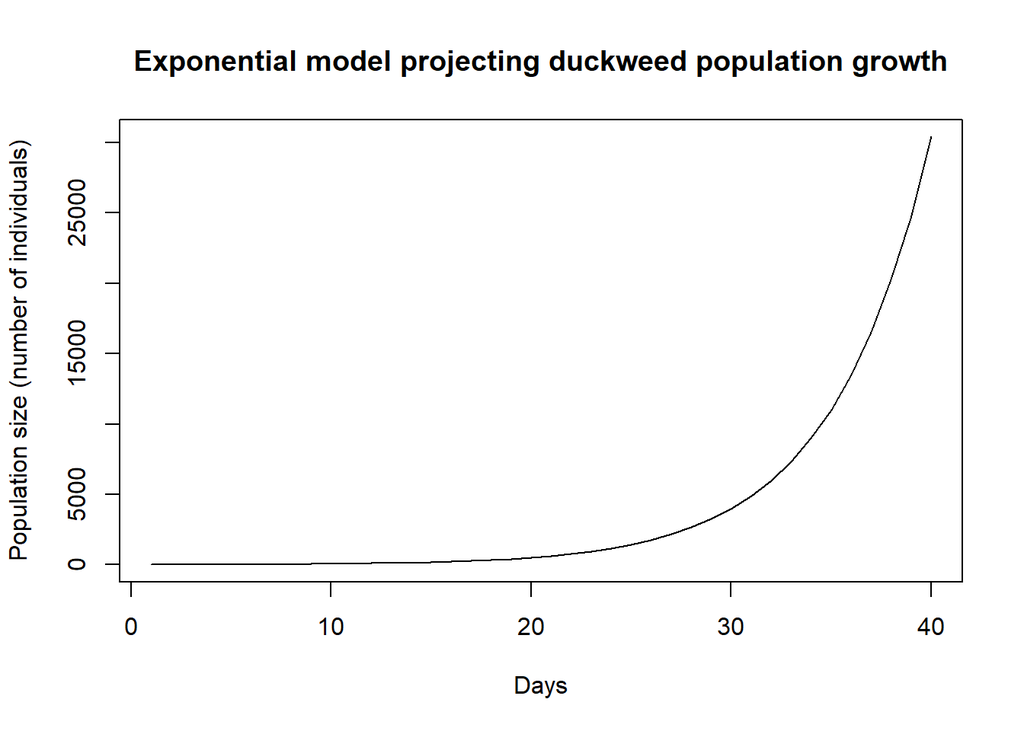

```r
# And here we simulate the growth of duckweeds over a 40-day period
N0 <- duckweed$pop_size[1]; t <- 1:40
cont.mat <- sapply(r, function(ri) N0 * exp(ri * t))
matplot(t, cont.mat, type = "l", col = 1,
        main="Exponential model projecting duckweed population growth",
     xlab="Days", ylab="Population size (number of individuals)")
```

#### 2.3.5.6 Simplifying the exponential growth calculation

Due to the ability to replace $\lambda$ for r and vice-versa, we have:

$$N_{t}=N_{0}e^{rt}$$

#### 2.3.5.7 Doubling time

If we need to know how much time it would take for a population to achieve twice as much its initial size, we replace N(final)/N(initial) with 2 in our exponential growth equation. We would then take the natural logarithm from both sides of the equation to solve, resulting in:

$$t_{double}=0.69/r$$

```r
# We can use this equation to calculate the doubling time for our experimental duckweeds:
double <- 0.69/r
```

The doubling time for our duckweeds is 3.40 days.

#### 2.3.5.8 Paper discussion and exponential modelling illustration: invasive hippos in Colombia

Shurin, J. B., Aranguren-Riaño, N., Duque Negro, D., Echeverri Lopez, D., Jones, N. T., Laverde‐R, O., … & Pedroza Ramos, A. (2020). Ecosystem effects of the world’s largest invasive animal. *Ecology, 101*(5), e02991.

[figure not shown]

Research about hippo invasion in Colombia

##### 2.3.5.8.1 Snapshot of the study

- An invasive population of hippopotamus (*Hippopotamus amphibus*) is showing an exponential growth in Colombia
- These large mammals were brought from Africa to the famous drug trafficker Carlos Scobar’s private zoo about 25 years ago
- Following Scobar’s death, the then abandoned animals started spreading in the region, going from 4 to 65 individuals in 25 years
- Hippos are considered as ecosystem engineers because they modify ecosystems by grazing on land and defecating in water bodies, thereby fertilizing aquatic systems
- The growth of this invasive population appears to be in an exponential phase, with numbers achieving thousands in the following decades if no control measures are taken or without density-dependent regulation (to be introduced in the following module)
- This study analyzed aquatic and terrestrial areas populated by hippos to conclude that this invasive species is substantially changing the environment by relocating nutrients from the soil to the water, resulting in cyanobacteria blooms. Continued unrestricted hippo population growth can then lead to water resource damage.
- Constrains to management: Actions to manage this invasive species are complicated by the social-ecological mismatch between the scientific consensus on the ecosystem threats posed by this invasion and the public perception of the presence of hippos as being positive (eg., animal being used for touristic purposes)

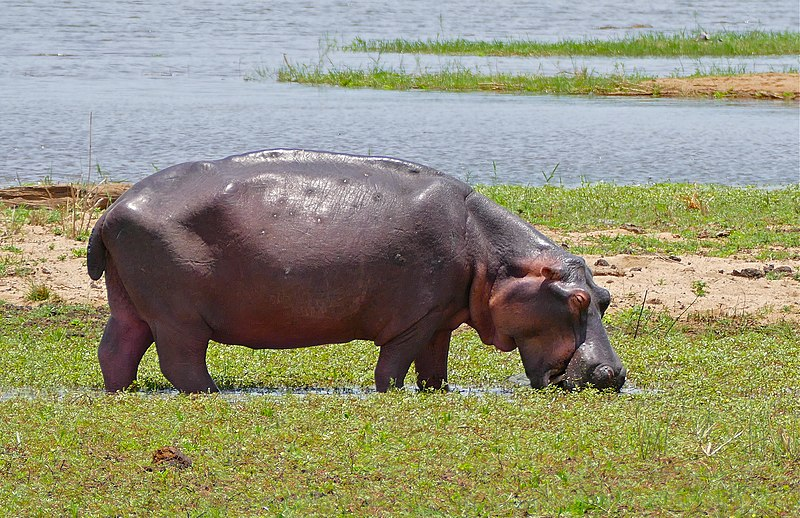

Grazing hippos by Bernard Dupont (https://commons.wikimedia.org/wiki/File:Hippo_%28Hippopotamus_amphibius%29_emaciated_specimen_grazing_on_Sabie_riverbank_…_%2833321050795%29.jpg), Creative Commons License CC-BY-SA-2.0

##### 2.3.5.8.2 Calculating the population growth of invasive hippos

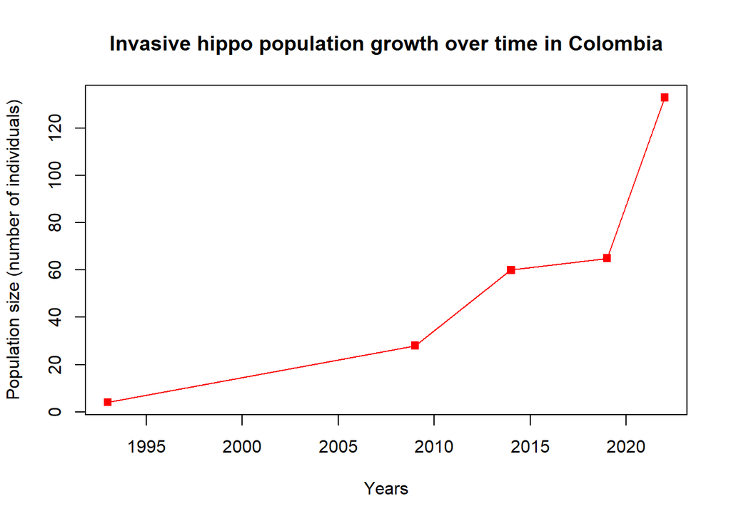

```r
# First, let's create a data frame containing dates and respective population counts as in Shurin (2020). We added additional records obtained from news outlets:
hippo <- data.frame(year=c(1993, 2009, 2014, 2019, 2022),pop_size=(c(4, 28, 60, 65, 133)))

# source for 2014: Kremer (2014)
# source for 2009: Romero (2009)
# source for 2022: Varona (2022)

plot(hippo$year, hippo$pop_size, type="o", pch=15, col="red",
     main="Invasive hippo population growth over time in Colombia",
     xlab="Years", ylab="Population size (number of individuals)")
```

```r
# Now, let's calculate the average yearly $\lambda$:
lambda <- (hippo[5, "pop_size"]/hippo[1, "pop_size"])^(1/(hippo[5, "year"]-hippo[1, "year"]))
```

The average yearly lambda is 1.13.

```r
# By taking the natural logarithm, we convert $\lambda$ to r
r<-log(lambda)
```

The intrinsic rate of increase is 0.12. This means that this invasive hippo population is growing at an average yearly rate of 12.08”%.

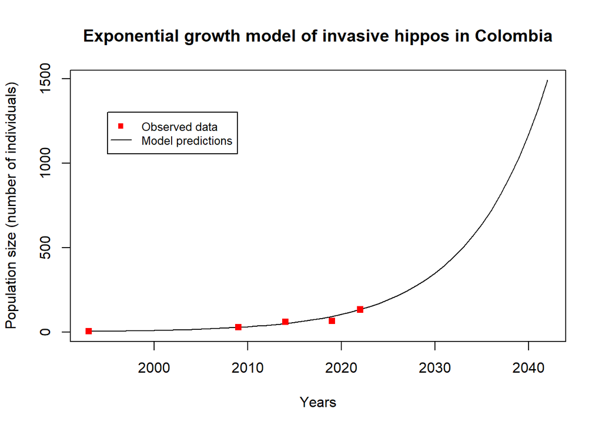

```r
# To predict population sizes, we first set our initial population size
initial<-hippo$pop_size[1]

# And we create an empty vector in which we will later include population sizes for the next 50 years
pred.pop.expon<-vector("numeric", 50)

# Our modelling starts with initially observed population sizes
pred.pop.expon[1]<-initial

# And we add a function to calculate population sizes according to our previously estimated growth rates
for(i in 2:50){
  pred.pop.expon[i]<-pred.pop.expon[i-1]*lambda
  }

# Adding a dataframe to include our predictions
hippo.model <- data.frame(year=c(1993:(1993+49)),pop_size=pred.pop.expon)

# And plotting predicitons and observed data
plot(hippo.model$year, hippo.model$pop_size,type="l",
     main="Exponential growth model of invasive hippos in Colombia",
     xlab="Years", ylab="Population size (number of individuals)")
points(hippo$year, hippo$pop_size,pch=15,col="red")
legend(1995, 1300, legend=c("Observed data", "Model predictions"),
       col=c("red", "black"), cex=0.8, lty= c(NA,1), pch=c(15,NA))
```

##### 2.3.5.8.3 Hippo invasion in Colombia: take-aways and future developments

- The research found an annual per capita growth rate of 0.11 x yr^-1 for invasive hippos, which is comparable to population growth rates in the native range and indicates a potential for quick spread of this invasive species in the next decades. The lack of predators in both native and invasive ranges (Sinclair, Mduma, & Brashares, 2003; Castelblanco-Martínez et al., 2021) is a key factor enabling uncontrolled hippo population growth.
- As a next step, refining population growth studies to include **stage structure** and **age at maturity** could help identifying useful management strategies, as there may be life history traits which are more relevant to population growth than others. For example, the population structure of hippos appears to be an important factor when predicting future invasion scenarios, as “half of those hippos are calves and juveniles, implying their reproductive rate will increase in the next three years” (Varona, 2022). You will learn about structured population models in the upcoming modules.

## 2.4 References

Castelblanco-Martínez, D. N., Moreno-Arias, R. A., Velasco, J. A., Moreno-Bernal, J. W., Restrepo, S., Noguera-Urbano, E. A., … & Jiménez, G. (2021). A hippo in the room: Predicting the persistence and dispersion of an invasive mega-vertebrate in Colombia, South America. *Biological Conservation, 253*, 108923.

Dyer, R. (2009). Biological data analysis using R (Doctoral dissertation, Ph. D thesis. Department of Biology, Center for the Study of Biological Complexity, Virginia Commonwealth Univ).

File:Common knapweed (Centaurea nigra) - geograph.org.uk - 492672.jpg. (2021, February 23). Wikimedia Commons, the free media repository. https://commons.wikimedia.org/w/index.php?title=File:Common_knapweed_(Centaurea_nigra)_-_geograph.org.uk_-_492672.jpg&oldid=535393847.

File:Malthus.png. (2020, September 20). Wikimedia Commons, the free media repository. https://commons.wikimedia.org/w/index.php?title=File:Malthus.png&oldid=465719566.

Gronewold, N. (2021). Comparative Conservation Strategy Efficacy for Grus japonensis and Grus americana: A Post-Policy Implementation Assessment. *Journal of International Wildlife Law & Policy, 24*(3-4), 224-250.

Jacobs, J. S., & Sheley, R. L. (1998). Observation: life history of spotted knapweed. *Rangeland Ecology & Management/Journal of Range Management Archives, 51*(6), 665-673.

Kremer, W. (2014, June 25). Pablo Escobar’s hippos: A growing problem. *BBC News*. https://www.bbc.com/news/magazine-27905743

Malthus, T. R. (1798). *An essay on the principle of population*. The Works of Thomas Robert Malthus, London, Pickering & Chatto Publishers, 1, 1-139.

Mills, L.S. (2012). *Conservation of wildlife populations*: Demography, genetics, and management. Wiley- Blackwell.

NBCUniversal News Group. (2014, July 1). Pablo Escobar’s hippos are running wild in Colombia. *NBCNews.com*. https://www.nbcnews.com/news/latin-america/pablo-escobars-hippos-are-running-wild-colombia-n145446

Romero, S. (2009, September 10). Colombia confronts drug lord’s legacy: Hippos. *The New York Times*. https://www.nytimes.com/2009/09/11/world/americas/11hippo.html

Shigesada, N. & Kawasaki, K. (1997) Biological Invasions: Theory and Practice (Oxford Univ. Press, Oxford).

Shurin, J. B., Aranguren-Riaño, N., Duque Negro, D., Echeverri Lopez, D., Jones, N. T., Laverde‐R, O., … & Pedroza Ramos, A. (2020). Ecosystem effects of the world’s largest invasive animal. *Ecology, 101*(5), e02991.

Sinclair, A. R., Mduma, S., & Brashares, J. S. (2003). Patterns of predation in a diverse predator–prey system. *Nature, 425*(6955), 288-290.

Spotted knapweed. (2023). Minnesota Department of Agriculture. https://www.mda.state.mn.us/plants/pestmanagement/weedcontrol/noxiouslist/spottedknapweed

Stevens, M.H. (2009). *A primer of ecology with R*. Springer.

Varona , A. O. (2022, November 18). Hippos in Colombia: What to do with them? | Graduate and Postdoctoral Studies | *Rice University*. https://graduate.rice.edu/news/current-news/hippos-colombia-what-do-them